# KLAKTERISASI POTENSI DESA WISATA DI JAWA BARAT PADA TAHUN 2020

Klakterisasi di bagi menjadi 3 yaitu:

1. Berpotensi tinggi
2. Berpotensi sedang
3. Berpotensi rendah

Klakterisasi dilakukan berdasarkan beberapa aspek penilaian pada ADWI 2022 yang datanya dimiliki dan juga ditambahkan satu aspek baru berdasarkan data yang dimiliki saat ini.

## 7 ASPEK PENILAIAN PADA ADWI 2022

1. DAYA TARIK PENGUNJUNG => Memiliki keunikan & keotentikan produk wisata yang bervariatif dan kreatif
2. HOMESTAY => Peningkatan standar kualitas pelayanan serta melestarikan disain arsitektur budaya lokal
3. DIGITAL DAN KREATIF => Akselerasi percepatan transformasi digital serta menciptakan konten-konten kreatif
4. SUVENIR => Menggali potensi kreativitas dan hasil karya masyarakat berbasis kearifal lokal
5. TOILET UMUM => Upaya pemenuhan sarana & prasarana demi kenyamanan wisatawan
6. CHSE => Penerapan fasilitas CHSE mengikuti standar nasional
7. KELEMBAGAAN DESA => Terbentuknya legalitas berbadan hukum dan pengelolaan yang berkelanjutan

## ASPEK TAMBAHAN

1. INFRASTRUKTUR PENDUKUNG => Memiliki infrastruktur yang memadai sebagai tujuan desa wisata

## ASPEK YANG DIGUNAKAN DALAM KLAKTERISASI

1. HOMESTAY
2. SUVENIR
3. CHSE
4. KELEMBAGAAN DESA
5. INFRASTRUKTUR PENDUKUNG

```python
import pandas as pd
import seaborn as sns
import matplotlib.pyplot as plt
import numpy as np

pd.set_option('display.max_columns', None)

import warnings
warnings.filterwarnings("ignore")
```

```python
data = pd.read_csv('jds-usecase-2.csv')
df = data.copy()
df.head(2)
```

|  | no | kode_provinsi | nama_provinsi | bps_kode_kabupaten_kota | bps_nama_kabupaten_kota | bps_kode_kecamatan | bps_nama_kecamatan | bps_kode_desa_kelurahan | bps_nama_desa_kelurahan | kemendagri_kode_kecamatan | kemendagri_nama_kecamatan | kemendagri_kode_desa_kelurahan | kemendagri_nama_desa_kelurahan | iks_2020 | ike_2020 | ikl_2020 | nilai_idm_2020 | status_idm_2020 | ekologi_airdesa | ekologi_dampak_cemar | ekonomi_transumum | ekonomi_jalan_desa | ekonomi_kualitas_jalan | ekonomi_status_bumdesa | ekonomi_status_bumdesa_bersama | ekonomi_bumdes_bid_pariwisata | sosial_bidang_modal_sosial_suku | sosial_bidang_modal_sosial_bahasa | sosial_bidang_modal_sosial_agama_mayoritas | … |
| --- | --- | --- | --- | --- | --- | --- | --- | --- | --- | --- | --- | --- | --- | --- | --- | --- | --- | --- | --- | --- | --- | --- | --- | --- | --- | --- | --- | --- | --- | --- |
| 0 | 1 | 32 | JAWA BARAT | 3201 | KABUPATEN BOGOR | 3201190 | GUNUNG PUTRI | 3201190006 | WANAHERANG | 32.01.02 | GUNUNG PUTRI | 32.01.02.2001 | WANAHERANG | 0.9486 | 0.85 | 0.3333 | 0.7106 | MAJU | 1 | 1 | 1 | 1 | 1 | 1 | 0 | 0 | 5 | 5 | 1 | … |
| 1 | 2 | 32 | JAWA BARAT | 3201 | KABUPATEN BOGOR | 3201190 | GUNUNG PUTRI | 3201190010 | BOJONG KULUR | 32.01.02 | GUNUNG PUTRI | 32.01.02.2002 | BOJONG KULUR | 0.9600 | 1.00 | 0.9333 | 0.9644 | MANDIRI | 1 | 1 | 1 | 1 | 1 | 1 | 0 | 0 | 2 | 3 | 1 | … |

### ASPEK YANG DIGUNAKAN DALAM KLAKTERISASI

Data yang digunakan antara lain:

- HOMESTAY => ekonomi_hotel => Terdapat hotel / penginapan di desa  
  0 : Tidak Ada  
  1 : Ada
- SUVENIR => ekonomi_produk_unggul => Terdapat produk unggulan di desa  
  0 : Tidak Ada  
  1 : Ada
- CHSE => ekologi_dampak_cemar => Dampak pencemaran lingkungan  
  0: Tidak Mempengaruhi Kesehatan  
  1: Menyebabkan Gangguan Kesehatan Ringan  
  2: Menimbulkan Penyakit/ Infeksi  
  3: Menimbulkan Kematian

  Pada data ekologi_dampak_cemar dilakukan sedikit perubahan menjadi:  
  0: Mempengaruhi Kesehatan (Menyebabkan Gangguan Kesehatan Ringan, Menimbulkan Penyakit/ Infeksi, Menimbulkan Kematian)  
  1: Tidak Mempengaruhi Kesehatan
- ekonomi_status_bumdesa => Status BumDes (Aktif/Tidak Aktif)  
  0: Tidak Aktif  
  1: Aktif
- ekonomi_bumdes_bid_pariwisata => BUMDes Pariwisata  
  0 : Tidak Ada  
  1 : Ada
- ekonomi_pariwisata_wisata_desa => Terdapat Bumdes Pariwisata Bidang Wisata desa  
  0 : Tidak Ada  
  1 : Ada
- ekonomi_pariwisata_agrowisata => Terdapat Bumdes Pariwisata Bidang Agrowisata  
  0 : Tidak Ada  
  1 : Ada
- ekonomi_pariwisata_wisata_alam => Terdapat Bumdes Pariwisata Bidang Wisata Alam  
  0 : Tidak Ada  
  1 : Ada
- ekonomi_pariwisata_transportasi => Terdapat Bumdes Pariwisata Bidang Transpotasi  
  0 : Tidak Ada  
  1 : Ada
- ekologi_airdesa => Ketersediaan Sumber Air di desa  
  1: Ya, Sepanjang Tahun  
  2: Ya, Kecuali Saat Tertentu Seperti Kemarau atau Kondisi Lainnya  
  3: Tidak Tersedia Sumber Air
- ekonomi_transumum => Angkutan Umum di desa  
  1: Ada, Trayek Tetap  
  2: Ada, Tanpa Trayek Tetap  
  3: Tidak Ada Angkutan Umum
- ekonomi_jalan_desa => Jalan di desa Dapat Dilalui Kendaraan Bermotor Roda Empat  
  1: Sepanjang tahun  
  2: Sepanjang tahun kecuali saat tertentu  
  3: Tidak dapat dilalui sepanjang tahun / Tidak Ada
- ekonomi_kualitas_jalan => Kualitas Permukaan Jalan di desa  
  1: Baik  
  2: Rusak sedang  
  3: Rusak parah
- sosial_bidang_pemukiman_sinyal => Sinyal telepon seluler / handphone di desa  
  1: Sinyak Kuat  
  2: Sinyal Lemah  
  3: Tidak Ada Sinyal

Dari data yang digunakan tersebut akan dilakukan scoring untuk mendapatkan desa yang memiliki kelembagaan desa yang memadai, cukup memadai, dan kurang memadai.

Keseluruhan poin akan dijumlahkan sehingga setiap desa akan mendapatkan total score masing-masing.  
Dari nilai total score tersebut akan dihitung indeks kelayakan yang akan digunakan untuk menentukan kelas setiap desa.

```python
aspekDesaWisata = df[['kemendagri_kode_kecamatan', 'kemendagri_nama_kecamatan', 'kemendagri_kode_desa_kelurahan',
          'kemendagri_nama_desa_kelurahan', 'ekonomi_hotel','ekonomi_produk_unggul','ekologi_dampak_cemar',
          'ekonomi_status_bumdesa','ekonomi_bumdes_bid_pariwisata', 'ekonomi_pariwisata_wisata_desa',
          'ekonomi_pariwisata_agrowisata','ekonomi_pariwisata_wisata_alam','ekonomi_pariwisata_transportasi',
          'ekologi_airdesa', 'ekonomi_transumum', 'ekonomi_jalan_desa', 'ekonomi_kualitas_jalan',
          'sosial_bidang_pemukiman_sinyal']]
aspekDesaWisata.head(2)
```

|  | kemendagri_kode_kecamatan | kemendagri_nama_kecamatan | kemendagri_kode_desa_kelurahan | kemendagri_nama_desa_kelurahan | ekonomi_hotel | ekonomi_produk_unggul | ekologi_dampak_cemar | ekonomi_status_bumdesa | ekonomi_bumdes_bid_pariwisata | ekonomi_pariwisata_wisata_desa | ekonomi_pariwisata_agrowisata | ekonomi_pariwisata_wisata_alam | ekonomi_pariwisata_transportasi | ekologi_airdesa | ekonomi_transumum | ekonomi_jalan_desa | ekonomi_kualitas_jalan | sosial_bidang_pemukiman_sinyal |
| --- | --- | --- | --- | --- | --- | --- | --- | --- | --- | --- | --- | --- | --- | --- | --- | --- | --- | --- |
| 0 | 32.01.02 | GUNUNG PUTRI | 32.01.02.2001 | WANAHERANG | 1 | 0 | 1 | 1 | 0 | 0 | 0 | 0 | 0 | 1 | 1 | 1 | 1 | 1 |
| 1 | 32.01.02 | GUNUNG PUTRI | 32.01.02.2002 | BOJONG KULUR | 1 | 0 | 1 | 1 | 0 | 0 | 0 | 0 | 0 | 1 | 1 | 1 | 1 | 1 |

```python
aspekDesaWisata['ekonomi_jalan_desa'] = aspekDesaWisata['ekonomi_jalan_desa'].replace(0, 3)
aspekDesaWisata['sosial_bidang_pemukiman_sinyal'] = aspekDesaWisata['sosial_bidang_pemukiman_sinyal'].replace(0, 3)
aspekDesaWisata['ekologi_dampak_cemar'] = aspekDesaWisata['ekologi_dampak_cemar'].replace([[1, 2, 3], 0], [0, 1])
aspekDesaWisata.head(2)
```

|  | kemendagri_kode_kecamatan | kemendagri_nama_kecamatan | kemendagri_kode_desa_kelurahan | kemendagri_nama_desa_kelurahan | ekonomi_hotel | ekonomi_produk_unggul | ekologi_dampak_cemar | ekonomi_status_bumdesa | ekonomi_bumdes_bid_pariwisata | ekonomi_pariwisata_wisata_desa | ekonomi_pariwisata_agrowisata | ekonomi_pariwisata_wisata_alam | ekonomi_pariwisata_transportasi | ekologi_airdesa | ekonomi_transumum | ekonomi_jalan_desa | ekonomi_kualitas_jalan | sosial_bidang_pemukiman_sinyal |
| --- | --- | --- | --- | --- | --- | --- | --- | --- | --- | --- | --- | --- | --- | --- | --- | --- | --- | --- |
| 0 | 32.01.02 | GUNUNG PUTRI | 32.01.02.2001 | WANAHERANG | 1 | 0 | 0 | 1 | 0 | 0 | 0 | 0 | 0 | 1 | 1 | 1 | 1 | 1 |
| 1 | 32.01.02 | GUNUNG PUTRI | 32.01.02.2002 | BOJONG KULUR | 1 | 0 | 0 | 1 | 0 | 0 | 0 | 0 | 0 | 1 | 1 | 1 | 1 | 1 |

```python
def scoring1(row):
    if row == 1:
        val=3
    else:
        val=0
    return val

def scoring2(row):
    if row == 1:
        val=3
    elif row == 2:
        val=2
    else:
        val=0
    return val
```

```python
aspekDesaWisata['ekonomi_hotel_score'] = aspekDesaWisata['ekonomi_hotel'].apply(scoring1)
aspekDesaWisata['ekonomi_produk_unggul_score'] = aspekDesaWisata['ekonomi_produk_unggul'].apply(scoring1)
aspekDesaWisata['ekologi_dampak_cemar_score'] = aspekDesaWisata['ekologi_dampak_cemar'].apply(scoring1)
aspekDesaWisata['ekonomi_status_bumdesa_score'] = aspekDesaWisata['ekonomi_status_bumdesa'].apply(scoring1)
aspekDesaWisata['ekonomi_bumdes_bid_pariwisata_score'] = aspekDesaWisata['ekonomi_bumdes_bid_pariwisata'].apply(scoring1)
aspekDesaWisata['ekonomi_pariwisata_wisata_desa_score'] = aspekDesaWisata['ekonomi_pariwisata_wisata_desa'].apply(scoring1)
aspekDesaWisata['ekonomi_pariwisata_agrowisata_score'] = aspekDesaWisata['ekonomi_pariwisata_agrowisata'].apply(scoring1)
aspekDesaWisata['ekonomi_pariwisata_wisata_alam_score'] = aspekDesaWisata['ekonomi_pariwisata_wisata_alam'].apply(scoring1)
aspekDesaWisata['ekonomi_pariwisata_transportasi_score'] = aspekDesaWisata['ekonomi_pariwisata_transportasi'].apply(scoring1)
aspekDesaWisata['ekologi_airdesa_score'] = aspekDesaWisata['ekologi_airdesa'].apply(scoring2)
aspekDesaWisata['ekonomi_transumum_score'] = aspekDesaWisata['ekonomi_transumum'].apply(scoring2)
aspekDesaWisata['ekonomi_jalan_desa_score'] = aspekDesaWisata['ekonomi_jalan_desa'].apply(scoring2)
aspekDesaWisata['ekonomi_kualitas_jalan_score'] = aspekDesaWisata['ekonomi_kualitas_jalan'].apply(scoring2)
aspekDesaWisata['sosial_bidang_pemukiman_sinyal_score'] = aspekDesaWisata['sosial_bidang_pemukiman_sinyal'].apply(scoring2)
aspekDesaWisata['total_score'] = aspekDesaWisata['ekonomi_hotel_score'] + aspekDesaWisata['ekonomi_produk_unggul_score'] + aspekDesaWisata['ekologi_dampak_cemar_score'] + aspekDesaWisata['ekonomi_status_bumdesa_score'] + aspekDesaWisata['ekonomi_bumdes_bid_pariwisata_score'] + aspekDesaWisata['ekonomi_pariwisata_wisata_desa_score'] + aspekDesaWisata['ekonomi_pariwisata_agrowisata_score'] + aspekDesaWisata['ekonomi_pariwisata_wisata_alam_score'] + aspekDesaWisata['ekonomi_pariwisata_transportasi_score'] + aspekDesaWisata['ekologi_airdesa_score'] + aspekDesaWisata['ekonomi_transumum_score'] + aspekDesaWisata['ekonomi_jalan_desa_score'] + aspekDesaWisata['ekonomi_kualitas_jalan_score'] + aspekDesaWisata['sosial_bidang_pemukiman_sinyal_score']
aspekDesaWisata = aspekDesaWisata.sort_values(by=['total_score'], ascending=False).reset_index(drop=True)

aspekDesaWisata.head(2)
```

|  | kemendagri_kode_kecamatan | kemendagri_nama_kecamatan | kemendagri_kode_desa_kelurahan | kemendagri_nama_desa_kelurahan | ekonomi_hotel | ekonomi_produk_unggul | ekologi_dampak_cemar | ekonomi_status_bumdesa | ekonomi_bumdes_bid_pariwisata | ekonomi_pariwisata_wisata_desa | ekonomi_pariwisata_agrowisata | ekonomi_pariwisata_wisata_alam | ekonomi_pariwisata_transportasi | ekologi_airdesa | ekonomi_transumum | ekonomi_jalan_desa | ekonomi_kualitas_jalan | sosial_bidang_pemukiman_sinyal | ekonomi_hotel_score | ekonomi_produk_unggul_score | ekologi_dampak_cemar_score | ekonomi_status_bumdesa_score | ekonomi_bumdes_bid_pariwisata_score | ekonomi_pariwisata_wisata_desa_score | ekonomi_pariwisata_agrowisata_score | ekonomi_pariwisata_wisata_alam_score | ekonomi_pariwisata_transportasi_score | ekologi_airdesa_score | ekonomi_transumum_score | … |
| --- | --- | --- | --- | --- | --- | --- | --- | --- | --- | --- | --- | --- | --- | --- | --- | --- | --- | --- | --- | --- | --- | --- | --- | --- | --- | --- | --- | --- | --- | --- |
| 0 | 32.02.21 | JAMPANGKULON | 32.02.21.2009 | TANJUNG | 1 | 1 | 1 | 1 | 1 | 1 | 1 | 1 | 1 | 1 | 2 | 1 | 1 | 2 | 3 | 3 | 3 | 3 | 3 | 3 | 3 | 3 | 3 | 3 | 2 | … |
| 1 | 32.04.05 | CILEUNYI | 32.04.05.2006 | CIBIRU WETAN | 1 | 1 | 1 | 1 | 1 | 1 | 1 | 1 | 0 | 1 | 1 | 1 | 1 | 1 | 3 | 3 | 3 | 3 | 3 | 3 | 3 | 3 | 0 | 3 | 3 | … |

Menurut (Yuniarti et al., 2018) Indeks kelayakan dapat dihitung dengan membandingkan nilai pada tiap kriteria dengan nilai maksimal pada tiap kriteria dalam persen. Kemudian skor yang didapat dari setiap variabel akan menentukan tingkat kelayakanya menggunakan rumus interval yaitu

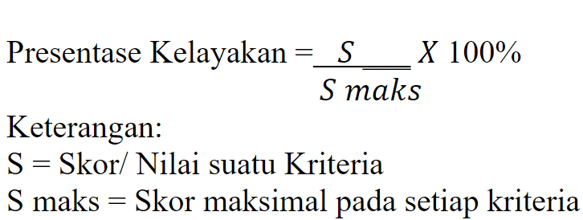

```python
aspekDesaWisata['indeks_kelayakan (%)'] = round((aspekDesaWisata['total_score'] / 42) * 100, 2)
aspekDesaWisata.head(2)
```

|  | kemendagri_kode_kecamatan | kemendagri_nama_kecamatan | kemendagri_kode_desa_kelurahan | kemendagri_nama_desa_kelurahan | ekonomi_hotel | ekonomi_produk_unggul | ekologi_dampak_cemar | ekonomi_status_bumdesa | ekonomi_bumdes_bid_pariwisata | ekonomi_pariwisata_wisata_desa | ekonomi_pariwisata_agrowisata | ekonomi_pariwisata_wisata_alam | ekonomi_pariwisata_transportasi | ekologi_airdesa | ekonomi_transumum | ekonomi_jalan_desa | ekonomi_kualitas_jalan | sosial_bidang_pemukiman_sinyal | ekonomi_hotel_score | ekonomi_produk_unggul_score | ekologi_dampak_cemar_score | ekonomi_status_bumdesa_score | ekonomi_bumdes_bid_pariwisata_score | ekonomi_pariwisata_wisata_desa_score | ekonomi_pariwisata_agrowisata_score | ekonomi_pariwisata_wisata_alam_score | ekonomi_pariwisata_transportasi_score | ekologi_airdesa_score | ekonomi_transumum_score | … |
| --- | --- | --- | --- | --- | --- | --- | --- | --- | --- | --- | --- | --- | --- | --- | --- | --- | --- | --- | --- | --- | --- | --- | --- | --- | --- | --- | --- | --- | --- | --- |
| 0 | 32.02.21 | JAMPANGKULON | 32.02.21.2009 | TANJUNG | 1 | 1 | 1 | 1 | 1 | 1 | 1 | 1 | 1 | 1 | 2 | 1 | 1 | 2 | 3 | 3 | 3 | 3 | 3 | 3 | 3 | 3 | 3 | 3 | 2 | … |
| 1 | 32.04.05 | CILEUNYI | 32.04.05.2006 | CIBIRU WETAN | 1 | 1 | 1 | 1 | 1 | 1 | 1 | 1 | 0 | 1 | 1 | 1 | 1 | 1 | 3 | 3 | 3 | 3 | 3 | 3 | 3 | 3 | 0 | 3 | 3 | … |

Menurut (Soekmadi & Kartodihardjo, 2010) untuk menilai indeks kelayakan terbagi menjadi 3 tingkatan yaitu :

- Indeks kelayakan > 66.6% : Kawasan yang layak dikembangkan (Berpotensi Tinggi = 1)
- Indeks kelayakan 33.3% hingga 66.66% : Kawasan belum layak dikembangkan (Berpotensi Sedang = 2)
- Indeks kelayakan < 33.3% : Kawasan tidak layak dikembangkan (Berpotensi Rendah = 3)

```python
def kelas(row):
    if row >= 66.6:
        val=1
    elif row >= 33.3 and row <= 66.66:
        val=2
    else:
        val=3
    return val
```

```python
aspekDesaWisata['kelas'] = aspekDesaWisata['indeks_kelayakan (%)'].apply(kelas)
aspekDesaWisata.head(2)
```

|  | kemendagri_kode_kecamatan | kemendagri_nama_kecamatan | kemendagri_kode_desa_kelurahan | kemendagri_nama_desa_kelurahan | ekonomi_hotel | ekonomi_produk_unggul | ekologi_dampak_cemar | ekonomi_status_bumdesa | ekonomi_bumdes_bid_pariwisata | ekonomi_pariwisata_wisata_desa | ekonomi_pariwisata_agrowisata | ekonomi_pariwisata_wisata_alam | ekonomi_pariwisata_transportasi | ekologi_airdesa | ekonomi_transumum | ekonomi_jalan_desa | ekonomi_kualitas_jalan | sosial_bidang_pemukiman_sinyal | ekonomi_hotel_score | ekonomi_produk_unggul_score | ekologi_dampak_cemar_score | ekonomi_status_bumdesa_score | ekonomi_bumdes_bid_pariwisata_score | ekonomi_pariwisata_wisata_desa_score | ekonomi_pariwisata_agrowisata_score | ekonomi_pariwisata_wisata_alam_score | ekonomi_pariwisata_transportasi_score | ekologi_airdesa_score | ekonomi_transumum_score | … |
| --- | --- | --- | --- | --- | --- | --- | --- | --- | --- | --- | --- | --- | --- | --- | --- | --- | --- | --- | --- | --- | --- | --- | --- | --- | --- | --- | --- | --- | --- | --- |
| 0 | 32.02.21 | JAMPANGKULON | 32.02.21.2009 | TANJUNG | 1 | 1 | 1 | 1 | 1 | 1 | 1 | 1 | 1 | 1 | 2 | 1 | 1 | 2 | 3 | 3 | 3 | 3 | 3 | 3 | 3 | 3 | 3 | 3 | 2 | … |
| 1 | 32.04.05 | CILEUNYI | 32.04.05.2006 | CIBIRU WETAN | 1 | 1 | 1 | 1 | 1 | 1 | 1 | 1 | 0 | 1 | 1 | 1 | 1 | 1 | 3 | 3 | 3 | 3 | 3 | 3 | 3 | 3 | 0 | 3 | 3 | … |

```python
df_Final = pd.merge(df, aspekDesaWisata[['kemendagri_kode_kecamatan', 'kemendagri_kode_desa_kelurahan', 'kelas']],
                    on=['kemendagri_kode_kecamatan', 'kemendagri_kode_desa_kelurahan'], how='inner')
df_Final.head(2)
```

|  | no | kode_provinsi | nama_provinsi | bps_kode_kabupaten_kota | bps_nama_kabupaten_kota | bps_kode_kecamatan | bps_nama_kecamatan | bps_kode_desa_kelurahan | bps_nama_desa_kelurahan | kemendagri_kode_kecamatan | kemendagri_nama_kecamatan | kemendagri_kode_desa_kelurahan | kemendagri_nama_desa_kelurahan | iks_2020 | ike_2020 | ikl_2020 | nilai_idm_2020 | status_idm_2020 | ekologi_airdesa | ekologi_dampak_cemar | ekonomi_transumum | ekonomi_jalan_desa | ekonomi_kualitas_jalan | ekonomi_status_bumdesa | ekonomi_status_bumdesa_bersama | ekonomi_bumdes_bid_pariwisata | sosial_bidang_modal_sosial_suku | sosial_bidang_modal_sosial_bahasa | sosial_bidang_modal_sosial_agama_mayoritas | … |
| --- | --- | --- | --- | --- | --- | --- | --- | --- | --- | --- | --- | --- | --- | --- | --- | --- | --- | --- | --- | --- | --- | --- | --- | --- | --- | --- | --- | --- | --- | --- |
| 0 | 1 | 32 | JAWA BARAT | 3201 | KABUPATEN BOGOR | 3201190 | GUNUNG PUTRI | 3201190006 | WANAHERANG | 32.01.02 | GUNUNG PUTRI | 32.01.02.2001 | WANAHERANG | 0.9486 | 0.85 | 0.3333 | 0.7106 | MAJU | 1 | 1 | 1 | 1 | 1 | 1 | 0 | 0 | 5 | 5 | 1 | … |
| 1 | 2 | 32 | JAWA BARAT | 3201 | KABUPATEN BOGOR | 3201190 | GUNUNG PUTRI | 3201190010 | BOJONG KULUR | 32.01.02 | GUNUNG PUTRI | 32.01.02.2002 | BOJONG KULUR | 0.9600 | 1.00 | 0.9333 | 0.9644 | MANDIRI | 1 | 1 | 1 | 1 | 1 | 1 | 0 | 0 | 2 | 3 | 1 | … |

```python
dataLatLong = pd.read_csv('desa_jawabarat.csv')
dataLatLong = dataLatLong.rename(columns={'kemendagri_kecamatan_kode':'kemendagri_kode_kecamatan',
                                          'kemendagri_kecamatan_nama':'kemendagri_nama_kecamatan',
                                          'kemendagri_kelurahan_kode':'kemendagri_kode_desa_kelurahan',
                                          'kemendagri_kelurahan_nama':'kemendagri_nama_desa_kelurahan'})
dataLatLong.head(2)
```

|  | id | kemendagri_provinsi_kode | kemendagri_kota_kode | kemendagri_kode_kecamatan | kemendagri_kode_desa_kelurahan | kemendagri_provinsi_nama | kemendagri_kota_nama | kemendagri_nama_kecamatan | kemendagri_nama_desa_kelurahan | bps_provinsi_kode | bps_kota_kode | bps_kecamatan_kode | bps_kelurahan_kode | bps_provinsi_nama | bps_kota_nama | bps_kecamatan_nama | bps_kelurahan_nama | latitude | longitude | kode_pos | status_adm |
| --- | --- | --- | --- | --- | --- | --- | --- | --- | --- | --- | --- | --- | --- | --- | --- | --- | --- | --- | --- | --- | --- |
| 0 | 1 | 32 | 32.01 | 32.01.01 | 32.01.01.1001 | JAWA BARAT | KAB. BOGOR | CIBINONG | PONDOK RAJEG | 32.0 | 3201.0 | 3201210.0 | 3.201210e+09 | JAWA BARAT | KABUPATEN BOGOR | CIBINONG | PONDOK RAJEG | -6.44385 | 106.82049 | 16913.0 | NaN |
| 1 | 2 | 32 | 32.01 | 32.01.01 | 32.01.01.1002 | JAWA BARAT | KAB. BOGOR | CIBINONG | KARADENAN | 32.0 | 3201.0 | 3201210.0 | 3.201210e+09 | JAWA BARAT | KABUPATEN BOGOR | CIBINONG | KARADENAN | -6.51589 | 106.80804 | 16913.0 | NaN |

```python
df_Viz = pd.merge(df_Final, dataLatLong[['kemendagri_kode_kecamatan','kemendagri_kode_desa_kelurahan', 'latitude', 'longitude']],
                  on=['kemendagri_kode_kecamatan', 'kemendagri_kode_desa_kelurahan'], how='left')
df_Viz.head(2)
```

|  | no | kode_provinsi | nama_provinsi | bps_kode_kabupaten_kota | bps_nama_kabupaten_kota | bps_kode_kecamatan | bps_nama_kecamatan | bps_kode_desa_kelurahan | bps_nama_desa_kelurahan | kemendagri_kode_kecamatan | kemendagri_nama_kecamatan | kemendagri_kode_desa_kelurahan | kemendagri_nama_desa_kelurahan | iks_2020 | ike_2020 | ikl_2020 | nilai_idm_2020 | status_idm_2020 | ekologi_airdesa | ekologi_dampak_cemar | ekonomi_transumum | ekonomi_jalan_desa | ekonomi_kualitas_jalan | ekonomi_status_bumdesa | ekonomi_status_bumdesa_bersama | ekonomi_bumdes_bid_pariwisata | sosial_bidang_modal_sosial_suku | sosial_bidang_modal_sosial_bahasa | sosial_bidang_modal_sosial_agama_mayoritas | … |
| --- | --- | --- | --- | --- | --- | --- | --- | --- | --- | --- | --- | --- | --- | --- | --- | --- | --- | --- | --- | --- | --- | --- | --- | --- | --- | --- | --- | --- | --- | --- |
| 0 | 1 | 32 | JAWA BARAT | 3201 | KABUPATEN BOGOR | 3201190 | GUNUNG PUTRI | 3201190006 | WANAHERANG | 32.01.02 | GUNUNG PUTRI | 32.01.02.2001 | WANAHERANG | 0.9486 | 0.85 | 0.3333 | 0.7106 | MAJU | 1 | 1 | 1 | 1 | 1 | 1 | 0 | 0 | 5 | 5 | 1 | … |
| 1 | 2 | 32 | JAWA BARAT | 3201 | KABUPATEN BOGOR | 3201190 | GUNUNG PUTRI | 3201190010 | BOJONG KULUR | 32.01.02 | GUNUNG PUTRI | 32.01.02.2002 | BOJONG KULUR | 0.9600 | 1.00 | 0.9333 | 0.9644 | MANDIRI | 1 | 1 | 1 | 1 | 1 | 1 | 0 | 0 | 2 | 3 | 1 | … |

```python
df_Viz = df_Viz.drop(['no','kode_provinsi', 'bps_kode_kabupaten_kota', 'bps_nama_kecamatan', 'bps_nama_desa_kelurahan',
                      'kemendagri_kode_kecamatan', 'kemendagri_kode_desa_kelurahan'], axis=1)

df_Viz.head(2)
```

|  | nama_provinsi | bps_nama_kabupaten_kota | bps_kode_kecamatan | bps_kode_desa_kelurahan | kemendagri_nama_kecamatan | kemendagri_nama_desa_kelurahan | iks_2020 | ike_2020 | ikl_2020 | nilai_idm_2020 | status_idm_2020 | ekologi_airdesa | ekologi_dampak_cemar | ekonomi_transumum | ekonomi_jalan_desa | ekonomi_kualitas_jalan | ekonomi_status_bumdesa | ekonomi_status_bumdesa_bersama | ekonomi_bumdes_bid_pariwisata | sosial_bidang_modal_sosial_suku | sosial_bidang_modal_sosial_bahasa | sosial_bidang_modal_sosial_agama_mayoritas | sosial_bidang_pemukiman_sinyal | ekonomi_hotel | ekonomi_jarak_hotel | ekonomi_menit_hotel | ekonomi_penghasilan | ekonomi_produk_unggul | ekonomi_umikrokecil_industri_rt | … |
| --- | --- | --- | --- | --- | --- | --- | --- | --- | --- | --- | --- | --- | --- | --- | --- | --- | --- | --- | --- | --- | --- | --- | --- | --- | --- | --- | --- | --- | --- | --- |
| 0 | JAWA BARAT | KABUPATEN BOGOR | 3201190 | 3201190006 | GUNUNG PUTRI | WANAHERANG | 0.9486 | 0.85 | 0.3333 | 0.7106 | MAJU | 1 | 1 | 1 | 1 | 1 | 1 | 0 | 0 | 5 | 5 | 1 | 1 | 1 | 1000 | 10 | 2 | 0 | 0 | … |
| 1 | JAWA BARAT | KABUPATEN BOGOR | 3201190 | 3201190010 | GUNUNG PUTRI | BOJONG KULUR | 0.9600 | 1.00 | 0.9333 | 0.9644 | MANDIRI | 1 | 1 | 1 | 1 | 1 | 1 | 0 | 0 | 2 | 3 | 1 | 1 | 1 | 300 | 3 | 3 | 0 | 8 | … |

```python
df_Viz['ekologi_airdesa'] = df_Viz['ekologi_airdesa'].replace([1, 2, 3], ['Ya, Sepanjang Tahun', 'Ya, Kecuali Saat Tertentu',
                                                                  'Tidak Tersedia Sumber Air'])
df_Viz['ekologi_dampak_cemar'] = df_Viz['ekologi_dampak_cemar'].replace([0, 1, 2, 3], ['Tidak Mempengaruhi Kesehatan',
                                                                               'Gangguan Kesehatan Ringan',
                                                                               'Menimbulkan Penyakit', 'Menimbulkan Kematian'])
df_Viz['ekonomi_transumum'] = df_Viz['ekonomi_transumum'].replace([1, 2, 3], ['Ada, Trayek Tetap', 'Ada, Tanpa Trayek Tetap',
                                                                      'Tidak Ada Angkutan Umum'])
df_Viz['ekonomi_jalan_desa'] = df_Viz['ekonomi_jalan_desa'].replace([0, 1, 2, 3], ['Tidak ada', 'Sepanjang tahun',
                                                                           'Sepanjang tahun kecuali saat tertentu',
                                                                           'Tidak dapat dilalui sepanjang tahun'])
df_Viz['ekonomi_kualitas_jalan'] = df_Viz['ekonomi_kualitas_jalan'].replace([1, 2, 3], ['Baik', 'Rusak sedang', 'Rusak parah'])
df_Viz['ekonomi_status_bumdesa'] = df_Viz['ekonomi_status_bumdesa'].replace([0, 1], ['Tidak aktif', 'Aktif'])
df_Viz['ekonomi_status_bumdesa_bersama'] = df_Viz['ekonomi_status_bumdesa_bersama'].replace([0, 1], ['Tidak aktif', 'Aktif'])
df_Viz['ekonomi_bumdes_bid_pariwisata'] = df_Viz['ekonomi_bumdes_bid_pariwisata'].replace([0, 1], ['Tidak ada', 'Ada'])
df_Viz['sosial_bidang_modal_sosial_agama_mayoritas'] = df_Viz['sosial_bidang_modal_sosial_agama_mayoritas'].replace([0, 1], ['Tidak ada', 'Ada'])
df_Viz['sosial_bidang_pemukiman_sinyal'] = df_Viz['sosial_bidang_pemukiman_sinyal'].replace([0, 1, 2], ['Tidak ada sinyal', 'Sinyal Kuat',
                                                                                               'Sinyal Lemah'])
df_Viz['ekonomi_hotel'] = df_Viz['ekonomi_hotel'].replace([0, 1], ['Tidak ada', 'Ada'])
df_Viz['ekonomi_penghasilan'] = df_Viz['ekonomi_penghasilan'].replace([1, 2, 3, 4, 5], ['Pertanian', 'Industri',
                                                                                'Perdagangan, Trans, dan Jasa', 'Pariwisata',
                                                                                'Lainnya'])
df_Viz['ekonomi_produk_unggul'] = df_Viz['ekonomi_produk_unggul'].replace([0, 1], ['Tidak ada', 'Ada'])
df_Viz['ekonomi_pariwisata_wisata_desa'] = df_Viz['ekonomi_pariwisata_wisata_desa'].replace([0, 1], ['Tidak ada', 'Ada'])
df_Viz['ekonomi_pariwisata_agrowisata'] = df_Viz['ekonomi_pariwisata_agrowisata'].replace([0, 1], ['Tidak ada', 'Ada'])
df_Viz['ekonomi_pariwisata_wisata_alam'] = df_Viz['ekonomi_pariwisata_wisata_alam'].replace([0, 1], ['Tidak ada', 'Ada'])
df_Viz['ekonomi_pariwisata_transportasi'] = df_Viz['ekonomi_pariwisata_transportasi'].replace([0, 1], ['Tidak ada', 'Ada'])
df_Viz['kelas'] = df_Viz['kelas'].replace([1, 2, 3], ['Berpotensi tinggi', 'Berpotensi sedang', 'Berpotensi rendah'])
```

```python
df_Viz =df_Viz.rename(columns={'bps_kode_kecamatan':'Id Kec', 'bps_kode_desa_kelurahan':'Id2012'})
df_Viz.head(2)
```

|  | nama_provinsi | bps_nama_kabupaten_kota | Id Kec | Id2012 | kemendagri_nama_kecamatan | kemendagri_nama_desa_kelurahan | iks_2020 | ike_2020 | ikl_2020 | nilai_idm_2020 | status_idm_2020 | ekologi_airdesa | ekologi_dampak_cemar | ekonomi_transumum | ekonomi_jalan_desa | ekonomi_kualitas_jalan | ekonomi_status_bumdesa | ekonomi_status_bumdesa_bersama | ekonomi_bumdes_bid_pariwisata | sosial_bidang_modal_sosial_suku | sosial_bidang_modal_sosial_bahasa | sosial_bidang_modal_sosial_agama_mayoritas | sosial_bidang_pemukiman_sinyal | ekonomi_hotel | ekonomi_jarak_hotel | ekonomi_menit_hotel | ekonomi_penghasilan | ekonomi_produk_unggul | ekonomi_umikrokecil_industri_rt | … |
| --- | --- | --- | --- | --- | --- | --- | --- | --- | --- | --- | --- | --- | --- | --- | --- | --- | --- | --- | --- | --- | --- | --- | --- | --- | --- | --- | --- | --- | --- | --- |
| 0 | JAWA BARAT | KABUPATEN BOGOR | 3201190 | 3201190006 | GUNUNG PUTRI | WANAHERANG | 0.9486 | 0.85 | 0.3333 | 0.7106 | MAJU | Ya, Sepanjang Tahun | Gangguan Kesehatan Ringan | Ada, Trayek Tetap | Sepanjang tahun | Baik | Aktif | Tidak aktif | Tidak ada | 5 | 5 | Ada | Sinyal Kuat | Ada | 1000 | 10 | Industri | Tidak ada | 0 | … |
| 1 | JAWA BARAT | KABUPATEN BOGOR | 3201190 | 3201190010 | GUNUNG PUTRI | BOJONG KULUR | 0.9600 | 1.00 | 0.9333 | 0.9644 | MANDIRI | Ya, Sepanjang Tahun | Gangguan Kesehatan Ringan | Ada, Trayek Tetap | Sepanjang tahun | Baik | Aktif | Tidak aktif | Tidak ada | 2 | 3 | Ada | Sinyal Kuat | Ada | 300 | 3 | Perdagangan, Trans, dan Jasa | Tidak ada | 8 | … |

```python
df_Viz.to_csv('CapstoneDatasetFinal.csv', index=False)
```

```python
datafinal = pd.read_csv('CapstoneDatasetFinal.csv')
datafinal.head()
```

|  | nama_provinsi | bps_nama_kabupaten_kota | Id Kec | Id2012 | kemendagri_nama_kecamatan | kemendagri_nama_desa_kelurahan | iks_2020 | ike_2020 | ikl_2020 | nilai_idm_2020 | status_idm_2020 | ekologi_airdesa | ekologi_dampak_cemar | ekonomi_transumum | ekonomi_jalan_desa | ekonomi_kualitas_jalan | ekonomi_status_bumdesa | ekonomi_status_bumdesa_bersama | ekonomi_bumdes_bid_pariwisata | sosial_bidang_modal_sosial_suku | sosial_bidang_modal_sosial_bahasa | sosial_bidang_modal_sosial_agama_mayoritas | sosial_bidang_pemukiman_sinyal | ekonomi_hotel | ekonomi_jarak_hotel | ekonomi_menit_hotel | ekonomi_penghasilan | ekonomi_produk_unggul | ekonomi_umikrokecil_industri_rt | … |
| --- | --- | --- | --- | --- | --- | --- | --- | --- | --- | --- | --- | --- | --- | --- | --- | --- | --- | --- | --- | --- | --- | --- | --- | --- | --- | --- | --- | --- | --- | --- |
| 0 | JAWA BARAT | KABUPATEN BOGOR | 3201190 | 3201190006 | GUNUNG PUTRI | WANAHERANG | 0.9486 | 0.8500 | 0.3333 | 0.7106 | MAJU | Ya, Sepanjang Tahun | Gangguan Kesehatan Ringan | Ada, Trayek Tetap | Sepanjang tahun | Baik | Aktif | Tidak aktif | Tidak ada | 5 | 5 | Ada | Sinyal Kuat | Ada | 1000 | 10 | Industri | Tidak ada | 0 | … |
| 1 | JAWA BARAT | KABUPATEN BOGOR | 3201190 | 3201190010 | GUNUNG PUTRI | BOJONG KULUR | 0.9600 | 1.0000 | 0.9333 | 0.9644 | MANDIRI | Ya, Sepanjang Tahun | Gangguan Kesehatan Ringan | Ada, Trayek Tetap | Sepanjang tahun | Baik | Aktif | Tidak aktif | Tidak ada | 2 | 3 | Ada | Sinyal Kuat | Ada | 300 | 3 | Perdagangan, Trans, dan Jasa | Tidak ada | 8 | … |
| 2 | JAWA BARAT | KABUPATEN BOGOR | 3201190 | 3201190009 | GUNUNG PUTRI | CIANGSANA | 0.9943 | 0.9667 | 0.8667 | 0.9425 | MANDIRI | Ya, Sepanjang Tahun | Gangguan Kesehatan Ringan | Ada, Trayek Tetap | Sepanjang tahun | Baik | Aktif | Tidak aktif | Tidak ada | 8 | 8 | Ada | Sinyal Kuat | Tidak ada | 500 | 30 | Perdagangan, Trans, dan Jasa | Ada | 20 | … |
| 3 | JAWA BARAT | KABUPATEN BOGOR | 3201190 | 3201190002 | GUNUNG PUTRI | GUNUNG PUTRI | 0.8914 | 0.8167 | 0.3333 | 0.6805 | BERKEMBANG | Ya, Kecuali Saat Tertentu | Gangguan Kesehatan Ringan | Ada, Trayek Tetap | Sepanjang tahun | Baik | Aktif | Tidak aktif | Tidak ada | 5 | 4 | Ada | Sinyal Kuat | Tidak ada | 0 | 0 | Perdagangan, Trans, dan Jasa | Tidak ada | 120 | … |
| 4 | JAWA BARAT | KABUPATEN BOGOR | 3201190 | 3201190004 | GUNUNG PUTRI | BOJONG NANGKA | 0.9600 | 0.9333 | 0.7333 | 0.8756 | MANDIRI | Ya, Kecuali Saat Tertentu | Tidak Mempengaruhi Kesehatan | Ada, Trayek Tetap | Sepanjang tahun | Baik | Aktif | Tidak aktif | Tidak ada | 3 | 3 | Ada | Sinyal Kuat | Tidak ada | 50000 | 20 | Industri | Ada | 15 | … |

```python
datafinal1 = pd.read_csv('Jabar_By_Desa_Jabar_By_Desa.csv', sep=';')
datafinal1.head()
```

|  | Desa | Desano | Id Kab | Id Kec | Id2012 | Kabkot | Kabkotno | Kecamatan | Kecno | Provinsi | Provno | Geometry | Objectid | Shape Area | Shape Leng |
| --- | --- | --- | --- | --- | --- | --- | --- | --- | --- | --- | --- | --- | --- | --- | --- |
| 0 | MALASARI | 1 | 3201 | 3201010 | 3201010001 | BOGOR | 1 | NANGGUNG | 10 | JAWA BARAT | 32 | MultiPolygon | 1 | 0,004993578 | 0,374383759 |
| 1 | BANTAR KARET | 2 | 3201 | 3201010 | 3201010002 | BOGOR | 1 | NANGGUNG | 10 | JAWA BARAT | 32 | MultiPolygon | 2 | 0,003061559 | 0,387303607 |
| 2 | CISARUA | 3 | 3201 | 3201010 | 3201010003 | BOGOR | 1 | NANGGUNG | 10 | JAWA BARAT | 32 | MultiPolygon | 3 | 0,001519939 | 0,196897578 |
| 3 | CURUG BITUNG | 4 | 3201 | 3201010 | 3201010004 | BOGOR | 1 | NANGGUNG | 10 | JAWA BARAT | 32 | MultiPolygon | 4 | 0,000917148 | 0,200464953 |
| 4 | NANGGUNG | 5 | 3201 | 3201010 | 3201010005 | BOGOR | 1 | NANGGUNG | 10 | JAWA BARAT | 32 | MultiPolygon | 5 | 0,000551860 | 0,112517877 |

```python
datafinal1.dtypes
```

```
Desa          object
Desano         int64
Id Kab         int64
Id Kec         int64
Id2012         int64
Kabkot        object
Kabkotno       int64
Kecamatan     object
Kecno          int64
Provinsi      object
Provno         int64
Geometry      object
Objectid       int64
Shape Area    object
Shape Leng    object
dtype: object
```

```python
datafinal.dtypes
```

```
nama_provinsi                                  object
bps_nama_kabupaten_kota                        object
Id Kec                                          int64
Id2012                                          int64
kemendagri_nama_kecamatan                      object
kemendagri_nama_desa_kelurahan                 object
iks_2020                                      float64
ike_2020                                      float64
ikl_2020                                      float64
nilai_idm_2020                                float64
status_idm_2020                                object
ekologi_airdesa                                object
ekologi_dampak_cemar                           object
ekonomi_transumum                              object
ekonomi_jalan_desa                             object
ekonomi_kualitas_jalan                         object
ekonomi_status_bumdesa                         object
ekonomi_status_bumdesa_bersama                 object
ekonomi_bumdes_bid_pariwisata                  object
sosial_bidang_modal_sosial_suku                 int64
sosial_bidang_modal_sosial_bahasa               int64
sosial_bidang_modal_sosial_agama_mayoritas     object
sosial_bidang_pemukiman_sinyal                 object
ekonomi_hotel                                  object
ekonomi_jarak_hotel                             int64
ekonomi_menit_hotel                             int64
ekonomi_penghasilan                            object
ekonomi_produk_unggul                          object
ekonomi_umikrokecil_industri_rt                 int64
ekonomi_umikrokecil_pariwisata                  int64
ekonomi_umikrokecil_perikanan                   int64
ekonomi_umikrokecil_pertanian                   int64
ekonomi_umikrokecil_peternakan                  int64
ekonomi_umikrokecil_lainnya                     int64
ekonomi_pariwisata_wisata_desa                 object
ekonomi_pariwisata_agrowisata                  object
ekonomi_pariwisata_wisata_alam                 object
ekonomi_pariwisata_transportasi                object
identitas_demografi_desa_total_penduduk         int64
kelas                                          object
latitude                                      float64
longitude                                     float64
dtype: object
```